# Exploratory Analysis

## Project title

An In-Depth Analysis of Crime Data in Los Angeles

### Authors

Zerui Guan(gzr2004@uw.edu) Yuanxi Li(yuanxili@uw.edu) Xinyi Zhou(xzhou34@uw.edu) Kaiyun Zheng(kaiyun04@uw.edu)

### Date

Summer 2023

### Abstract

Our main question is analyzing the complex patterns of urban crime in Los Angeles，this question is important because it is useful information for public safety.To address the question, we will create data visualizations to discern crime trends and hotspots.In addition,we will try to make some analysis about the area with the highest frequency of crime,we aim to create a safer LA society and call for people’s attention on crime through this project.

### Keywords

1. Temporal Crime Patterns
2. Crime Hotspots
3. Geographical Crime Distribution
4. Crime in Los Angeles
5. Time-based Crime Trends

### Introduction

Our project seeks to decode the intricate patterns of urban crime in Los Angeles using detailed crime datasets. We aim to identify trends, pinpoint crime hotspots. Our mission is to furnish policymakers with incisive analyses, equipping them to sculpt informed, effective public policy. We strive to bolster the safety of Los Angeles communities.

The principal research questions guiding our project are:

1.Is there a temporal pattern to crime rates, such as fluctuations over the day, week, or year? 2.What are the crime hotspots in Los Angeles? 3.What area has most frequent crime incidents over the dataset? Compared to other areas, how does the most frequent crime area differ from the distribution of the types of crime committed? 4.What is the distribution of crime incidents over time in a day? In each time slot, what is the trend or distribution of types/locations of crime committed.

These questions stem from an urgent need to better understand the dynamics of crime in our cities. Uncovering patterns in crime can shine a light on the deeper, often systemic causes. These insights can help policymakers and law enforcement to more strategically allocate resources, implementing preventative measures in areas and times where crime is predicted to occur. Furthermore, through a comprehensive understanding of crime distribution and types, we can inform more targeted social and economic policies to address root causes.

The importance of these questions lies not only in their potential to help us respond to crime effectively but also in their potential to proactively shape a safer city. With our analysis, we aim to contribute to making Los Angeles safer and more secure for all its residents.

### Related Work

The project extensively examines crime trends and statistics in Los Angeles, employing comprehensive datasets. It aspires to inform and shape public policy, augmenting the community’s overall safety. The role of crime analysis has become increasingly vital in the context of urban security and the development of policy, culminating in an emphasis on utilizing data to devise intelligent strategies for crime deterrence and the enforcement of laws.

Previous work in this area has yielded insightful findings. Campedelli, Aziani, and Favarin (2021) explored the immediate effects of COVID-19 containment policies on crime, shedding light on short-term aftermaths in Los Angeles, a relevant aspect in considering temporal crime patterns (Campedelli, G. M., Aziani, A., & Favarin, S., 2021). Massenkoff and Chalfin (2022) conducted an analysis showing that, when adjusted for activity rates, public safety worsened in 2020, providing a critical perspective on crime rates (Massenkoff, M., & Chalfin, A., 2022). Additionally, a report by FOX LA (2023) highlights a decrease in LA’s crime in 2023 compared to the previous year, aligning with the objective of this study to monitor and analyze temporal crime fluctuations (FOX LA, 2023).

Collectively, these research efforts and reports emphasize the intricate nature of urban crime, highlighting the need for a data-driven approach to its analysis. The knowledge gleaned from this ongoing research has the potential to inform the strategic deployment of resources, proactive measures, and specific socio-economic policies – all aimed at making the city safer—this body of work aids in efficiently responding to crime and proactively formulating standards to enhance public safety. Our project aligns with these goals, striving to foster a safer living environment for the inhabitants of Los Angeles.

Reference:

Campedelli, G. M., Aziani, A., & Favarin, S. (2021). Exploring the immediate effects of COVID-19 containment policies on crime: An empirical analysis of the short-term aftermath in Los Angeles.*American Journal of Criminal Justice*, *46*(5), 704-727.

FOX LA. (2023). Crime in LA down in 2023 compared to last year, data shows. FOX LA. https://www.foxla.com/news/crime-in-la-down-in-2023-compared-to-last-year-data-shows

Massenkoff, M., & Chalfin, A. (2022). Activity-adjusted crime rates show that public safety worsened in 2020.*Proceedings of the National Academy of Sciences*, *119*(46), e2208598119.

### Implications

Understanding the temporal patterns of crime rates can have significant impacts. Technologists and designers can create algorithms and models to develop more accurate crime prediction and prevention systems by analyzing these historical crime data and identifying crime patterns during specific time ranges. Policymakers can use this information to implement targeted interventions and policies during high crime.

Identifying crime hotspots in Los Angeles can help build crime hotspot maps, reflecting the relationship between locations and criminal incidents. It can help technologists and designers develop location-based crime reporting and alert systems, providing real-time crime updates and safety notifications to residents and visitors in high-risk areas. Policymakers can also utilize this information to allocate resources for increased patrols, surveillance, and community engagement initiatives in these crime hotspots.

Knowing the crime incident frequency in different areas inside Los Angeles is also essential. Designers can look at urban design to see if the city’s planning is sound and if a new police station is needed to reduce crime. Technology experts can provide better advice to law enforcement agencies and better links between police stations and crime locations to help enforce the law effectively. Policymakers can better plan and deploy programs to deal with crime incidents.

Studying different types of criminal incidents with their locations can help designers make better urban planning, taking more consideration and avoiding further damage. The technologists can give more detailed reports on criminal predictions, providing specific visualization to raise public awareness. For policymakers, this information can serve as a basis for implementing community-oriented programs, social services, and neighborhood revitalization efforts to effectively address the root causes of crime in the most affected area.

### Limitations & Challenges

The first challenge is ensuring the data’s quality and completeness. For instance, underreported or misclassified crimes can skew the analysis and lead to inaccurate results. These results will misguide the researchers and citizens, leading to an erroneous understanding and conclusions. This outcome contradicts our purpose of making this data visualization.

The second challenge is the level of detail in the crime data can significantly impact the analysis. Identifying crime hotspots or detecting temporal patterns may be difficult if the data are not sufficiently granular. The level of detail is essential in finding the pattern of the data. However, some elements might need to be more specific, which makes analysis difficult to generate. Thus, the pattern might be biased and generated.

The third challenge is findings from Los Angeles may not generalize to other cities due to unique local factors. Since different cities have different situations, it takes work to generalize them by a format of the findings from LA. Thus, we have to be careful when analyzing the data and making conclusions.

### Summary Information

Crime Dataset

Crime number of Rows:317854

Crime number of Columns:28

Number Of Area:21

Number Of Crime Type:133

Eldest Victim Age:120

The summary of the crime dataset indicates a largenumber of cases.This data encompasses 21 distinct areas, and the range of crime types is notably diverse, with as many as 133 different classifications. One particularly striking detail from the dataset is the age of the eldest victim, marked at an unusual 120 years. This fact underscores the vulnerability of individuals across all age groups to crime.In addition,this extensive dataset provides a comprehensive overview of crime trends and patterns.

| crime_Num_Rows | crime_Num_Columns | Num_Of_Area | Num_Of_Crime_Type | Eldest_Victim_Age |
| --- | --- | --- | --- | --- |
| 317854 | 28 | 21 | 133 | 120 |

### Table

The first table is classified by the age of Victims, with an interval of 10 years old, listing the number of Victims in each age group. This table not only allows people to understand the age distribution of victims more intuitively, but also can find patterns from it. The Second table classifies the area and lists the number of crime incidents in each area, with the highest number on 77th Street. Presenting in this way allows people to quickly understand the security situation of each area.

| unknown_gender | female_vict |
| --- | --- |
| 41406 | 114866 |

| age_groups | Freq |
| --- | --- |
| 0-10 | 78503 |
| 10-20 | 8197 |
| 20-30 | 54921 |
| 30-40 | 64192 |
| 40-50 | 44215 |
| 50-60 | 35465 |
| 60-70 | 21369 |
| 70-80 | 8061 |
| 80-90 | 2302 |
| 90-100 | 506 |
| 100-110 | 122 |
| 110-120 | 0 |

| AREA.NAME | Count |
| --- | --- |
| 77th Street | 20962 |
| Central | 18810 |
| Devonshire | 12381 |
| Foothill | 10966 |
| Harbor | 14131 |
| Hollenbeck | 12557 |
| Hollywood | 16988 |
| Mission | 13002 |
| N Hollywood | 16259 |
| Newton | 15651 |
| Northeast | 13798 |
| Olympic | 15650 |
| Pacific | 19116 |
| Rampart | 14438 |
| Southeast | 16965 |
| Southwest | 17568 |
| Topanga | 12799 |
| Van Nuys | 13699 |
| West LA | 14837 |
| West Valley | 12640 |
| Wilshire | 14637 |

### Chart 1

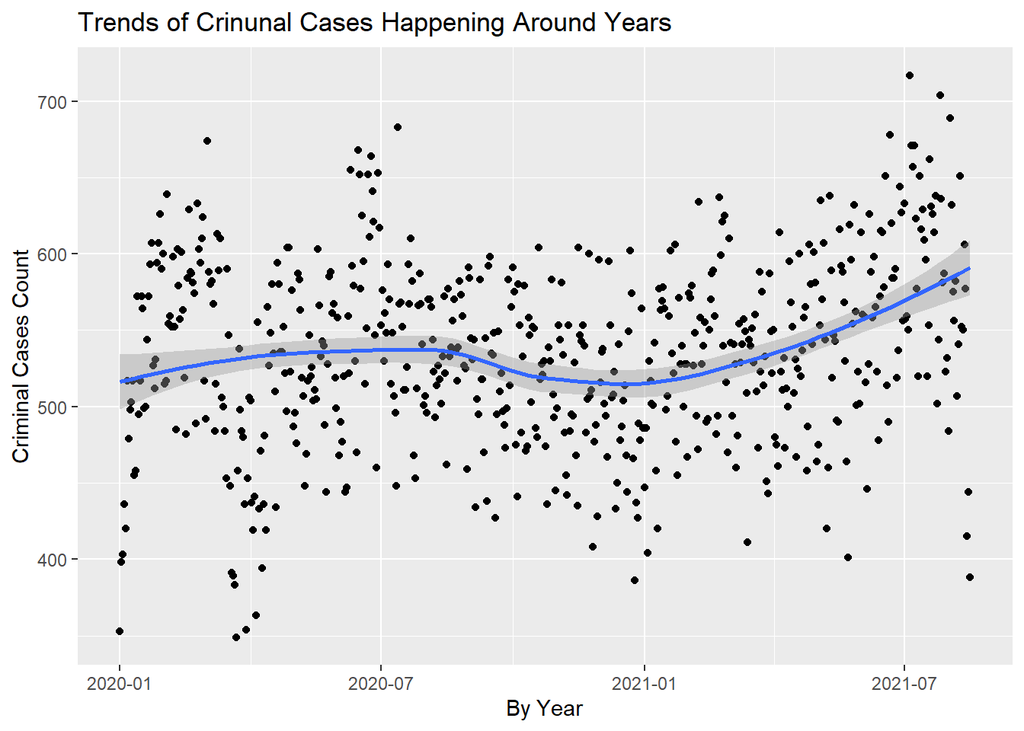

### Chart 2

The reason for choosing this chart is that the map of crime hot spots in Los Angeles will reflect the relationship between locations and the criminal incidents. This information is important to citizens because they can notice the high-risk area and get crime notifications to protect themselves.Moreover, this map also can help for research and the management of allocating the police resources.According to the map,central LA shows the darkest purple, indicating a relatively high number of criminal incidents in this area. The closer to the north and south, the lighter the purple color and the fewer incidents. In the fringe areas of LA, it is mainly gray, and the number is relatively small, mostly below 100.

[interactive chart not shown]

### Chart 3

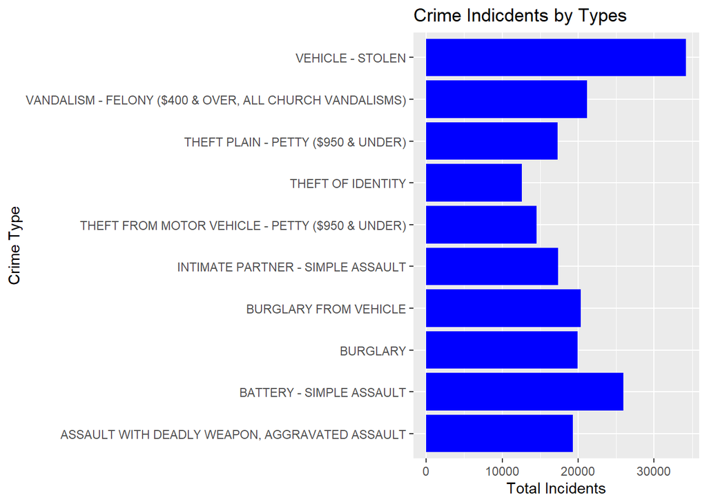